# Why Dont Students Like School.Willingham2021.2e.为什么学生不喜欢上学

# 结语

20世纪80年代初我还在杜克大学学习时，著名作家雷诺兹·普莱斯（Reynolds Price）是杜克大学教职员工中为数不多的名流之一。他经常戴着一条长长的狸红色围巾，迈着大步在校园里走来走去，他似乎并没有意识到自己很是引人注目。

当我参加普莱斯的创意写作研讨会时，他展现出我们学生所期望的艺术家独有的气质，他彬彬有礼，讲述着他与名人的故事。我们不仅尊重他，而且还敬仰他。即便如此，他还是和蔼可亲，对我们每个人都很认真，让我们喜出望外。

想象一下我们有多震惊，当听到普莱斯告诉我们任何作家都应该先预设出一个关于读者的情景再动笔：读者真想把书丢到一边，看看电视，喝喝啤酒，或者打打高尔夫。他的此番发言就像是在一个华丽的聚会上燃爆了一颗臭气弹。看电视？喝啤酒？我们以为我们是在为有欣赏力和有文化的读者写作，这听起来好像是普莱斯在教我们要迎合他人。后来在学期末我才明白，他只是在明确一个相当浅显的原则：如果你的作品无趣，为什么要要求别人去读？

多年以后，我透过认知心理学而非文学的视角来理解这些话。阅读是一种精神行为，它实际上改变了读者的思考过程。因此，每一篇散文或诗歌都是一种提案：“跟着我，相信我，让我带你踏上一段心灵之旅。虽然这条路时而坎坷陡峭，但参与这场冒险肯定对你大有益处。”读者可能接受你的邀请，但其思考过程不会就此停止。每走一步，你的读者都可能得出结论，认为这个旅途太过艰险，或者场景太过乏味，从而结束这次精神之旅。因此，作者必须在脑海中时刻关注付出时间和努力的读者是否得到了充分的回报。需要读者付出努力的比例越高，能继续阅读的人就越少，作家发现自己在这条路上孤独的可能性也会增加。

我认为这个比喻也适用于教学。教师试图引导学生往某个特定方向走，或者是探索更广阔的新领域。即使对教师来说，这也可能是一个新的环境，他们的旅程是并肩而行的。教师总是鼓励学生继续前进，遇到障碍时不要灰心丧气，利用过往经历踏平道路，欣赏着风景可能带来的壮美和敬畏。正如作者必须说服读者不要放弃这本书一样，教师也必须说服学生不要中断学习。因此，教学也是一种劝说的行为1。

那么，你如何说服学生跟随你学习呢？你可能想到的第一个答案就是人们总跟随受尊敬、给予鼓励的人学习。确实如此。如果你获得了学生的尊重，他们会努力集中注意力，这不仅是为了取悦你，也是信任你。如果你认为有些事情值得去了解，他们就会做好相信你的准备。问题是学生（和教师）对自己的心智活动控制有限。

虽然我们认为自己有决定关注什么的控制力，但涉及关注的焦点时，我们的大脑有自己的愿望和欲望。例如，你想坐下来读一些你知道会很枯燥但你仍然想仔细阅读的东西，比如一份报告。尽管你的意图是好的，但是你会发现自己在想别的事情，双眼就是简单扫过文字。同样，我们大多数人都有一位我们喜欢的教师，虽然他没有条理，或者说他有点迟钝，但他亲和认真。我在第1章中说过，听起来很有趣的内容并不能保证人们的专注力。还记得我前文提到的7年级教师的性教育课吗？学生有想要理解或取悦教师的愿望，但这并不能保证他们能持续专注。

那么，教师如何才能最大限度地让学生随其学习呢？我的另一位大学写作老师给了我答案，她说：“大部分的写作是预测读者的反应。”为了正确引导读者的心理旅程，你必须知道每个句子会把他们引向何处。读者会觉得有趣、困惑、有诗意还是具有攻击性？读者的反应不仅取决于你写的东西，也取决于读者是谁。一个简单的句子“教学就像写作”，会让学前班教师和销售员产生不同的理解。为了预测读者的反应，你必须了解他的个性、品味、偏好和背景知识。我们都听说过“了解你的受众”这个建议。我的大学老师解释了为什么这对写作来说是正确的，但我相信这对教学来说亦是如此。

因此，为了确保你的学生跟随你学习，你必须让他们感兴趣；为了确保他们的兴趣，你必须预测他们的反应；而为了预测他们的反应，你必须了解他们。“了解你的学生”是这本书内容的精髓。这句箴言听起来很像祖母心理学。如果你不知道你应该了解你的学生（我肯定你知道），你的祖母会告诉你这是一个好建议。难道认知科学就不能比你的祖母做得更好吗？

认知科学可以通过详细阐述给响亮的口号注入细节。学生的有些事情你应该知道，但有些事情你可以放心大胆地选择性忽略。在具备这些知识之后，你还可以采取一些行动，但是不要采取一些听起来很有道理但很可能适得其反的行动。表1总结了本书每一章的认知原则、运用它们所需要的知识类型，以及我认为最重要的课堂启示。

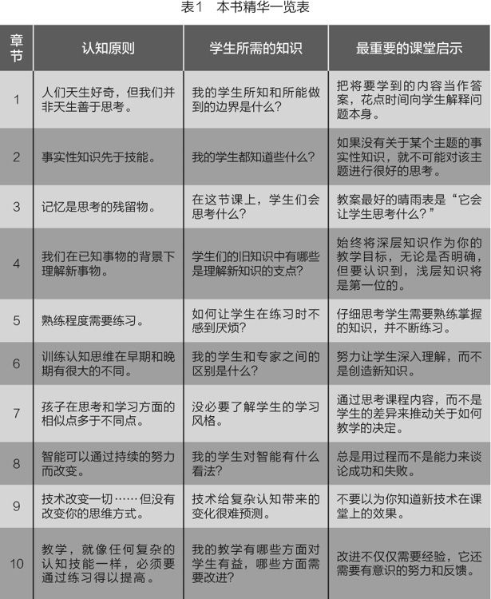

认知心理学家知道的其实比这10条认知原则多。这些原则被选中的原因，是它们符合四个标准。

标准1：正如本书前言中所描述的那样，这些原则中的每一条都是真理，无论它是在实验室还是在课堂里，是当独自一人还是处在一个团体中。大脑的复杂性意味着其属性经常随环境而发生变化。

标准2：每个原则都是基于大量的数据，而不仅仅是一两个研究，这意味着即便上述原则有误，它也接近真理了。我不认为10年后我会改写并推出本书的第三版，仅仅因为出现了颠覆性的数据而推翻书中的任何结论从而导致我删除任意一章。

标准3：使用或不使用原则会对学生的表现产生相当大的影响。认知心理学家知道很多可以运用在课堂上的其他方法，但应用这些原则的效果有限，所以这些方法是否需要推广尚未明确。

标准4：在确定一项原则时，我必须相当明了人们会利用它来做什么。例如，“专注力是学习的必要条件”，尽管它符合其他三个标准，但没有入选，因为它没有为教师的行动提供有效的指导。

我认为这些原则可以带来真正的改变，但这并不意味着运用这些原则很容易。“只要你运用我的秘诀，你就是一个了不起的教师”，这并不现实。表1中列出的所有原则都需要有良好的判断力，其中任何一条都可能被过度使用或曲解使用。如果认知科学不能提供明确的指导，那么，它在教育实践中的作用又是什么呢？

教育与其他研究领域类似，科学发现是有用的，但不起决定性作用。建筑师在设计办公楼时会使用物理学原理，但他们也会遵循美学原理和预算规则。同样，认知科学的知识对于规划你的教学内容和方式是有帮助的，但它并不是教学的全部，事情不是到此就结束了。

我认为认知科学在两个方面对教师有用。首先，认知科学可以帮助教师在相互冲突的顾虑中找到平衡。课堂毕竟不只是认知的地方，它还存在着情感、社交、激励等。这些不同的因素促使教师关注不同的问题，它们有时会发生冲突。也就是说，认知上最佳的练习可能是缺少动机的实践。了解认知科学原理可以帮助教师平衡课堂上不同的或者相互冲突的关注点。其次，认知科学的原则可以约束教学实践。物理学原理并没有为土木工程师确切地规定如何建造一座桥，但它们让他预先判断出如果他建造了这座桥，这座桥的性能如何。同样地，认知科学原理也没有规定如何教学，但它们可以帮助你预测你的学生有可能学到多少东西。如果你遵循这些原则，你就能使学生的成长最大化。

教育是将世代积累的智慧传递给孩子，我们强烈地相信它的重要性，因为我们知道，它为每个孩子以及其他所有人都带来了更好生活的希望。如果我们不利用科学积累的智慧来指导我们教育孩子的方法，那确实是一件憾事。这就是撰写《为什么学生不喜欢上学？》一书的目的。教育铸就更好的大脑，而关于头脑的知识可以成就更好的教育。

1 我相信普莱斯会同意将其忠告应用于教学，关于教学，他后来写道：“如果你的方法只对本身就专注的学生适用，那么你就要重新设计方法，否则你就是失败的。”——作者注

# 术语表

抽象知识（Abstract Knowledge）

知识适用于许多情况，其描述与任何特定情况无关。分类通常是抽象的，比如“狗”这个概念可以独立于任何特定的狗而被定义。解决问题也可能是抽象的，比如知道如何解决一个长除法问题与你可能除的任何特定数字无关。

自动的/自动性（Automatic/Automaticity）

如果一个过程只需要很少或者不需要注意力资源，那么这个过程就是自动的。如果环境中存在合适的诱因，即使不希望它发生，它也可能发生。

自动驾驶（Autopilot）

一个常见的语言术语，而不是一个技术术语。这种感觉就像你正在做一件复杂的事情，但实际上并不需要时刻想着它。开车就是个典型的例子，你在红灯前停车，转弯时打信号灯，变道时看后视镜，所有这些动作几乎都不需要你思考。

背景知识（Background Knowledge）

了解世界万物的常识。它可以是关于任何话题的，比如天空是蓝色的，圣马力诺靠近亚得里亚海，等等。背景知识（相关话题）对阅读理解和批判性思维至关重要。

组块记忆（Chunking）

将较小的知识单位组合在一起的过程（例如，字母“b”、“e”和“d”组成一个单词“bed”）。分块是解决工作记忆空间限制的一个重要方法。注意，分块需要来自长期记忆的信息。在长期记忆中存在“bed”这个词语，看到字母“b”“e”“d”才会意识到它们可以组成“bed”（床）这个单词。

认知能力（Cognitive Ability）

在某种类型的思维中取得成功的能力或技能。基本上相当于你做某事的能力。例如，用文字或数字思考。与认知风格形成鲜明对比。

认知风格（Cognitive Style）

某种特定方式思考的偏好或倾向。例如，以语言或视觉思维图像的方式。基本上相当于你喜欢如何做某事。一种风格并不优于另一种风格，但如果你使用自己喜欢的风格，应该比被迫使用不喜欢的风格更容易成功。

具体知识（Concrete Knowledge）

与抽象知识相比，具体知识处理的是具体的细节。你可能知道有几个物体是“狗”，所以你知道那些特定的物体是狗，但是你不会认出一只新狗，因为你在记忆中没有“狗”的抽象概念。

确认偏差（Confirmation Bias）

一旦我们持有一个执念，我们会不自觉地把含糊不清的证据解释为与我们的信念相一致，如果我们为其寻找证据，我们只会寻找支持它的证据，而不是反驳它的证据。

填鸭式学习（Cramming）

考试前把所有的练习（或知识）都死记硬背。

暗示（Cue）

唤起记忆的环境中的事物或能唤起记忆的想法。

深层知识（Deep Knowledge）

特点是深刻的理解和具体的例子，以及如何将两者结合在一起。有深层知识的人可以扩展他们的知识到新的例子，可以考虑关于它的假设问题。与死记硬背的知识和浅层知识相反。

刻意练习（Deliberate Practice）

要求你在一项复杂的任务中选择一个小部分进行改进。你寻求对你所做的事情的反馈，并尝试新事物来努力提高。刻意练习被理解为是需要付出努力的，因为它需要一定的专注力。

数字移民（Digital Immigrant）

指在长大过程中没有使用数字设备的人，也就是在20世纪80年代中期之前出生的人。有人指出他们在使用数字设备时感到不舒服，就像一个人与不同母语的人待在一起。此外，有人提出，持续使用数字设备实际上改变了认知处理和偏见。与数字原生代形成对比。

数字原生代（Digital Native）

指在长大过程中使用数字设备的人。这个词在2001年流行起来，指的是在20世纪80年代中期或之后出生的人。由于他们经常使用数字设备，人们认为这些人不仅使用起来得心应手，而且思维方式与众不同。与数字移民形成对比。

贴现率（Discount Rate）

近期的美好事物或经历与更遥远的未来的相对价值。你不久的将来可能得到的奖励比你在更遥远的将来可能得到的同样的奖励更有价值。奖励的价值随着时间的推移而急剧下降，而且越年轻越明显。在其他领域也被称为延迟贴现、短时贴现、时间贴现或时间偏好。

分散练习（Distributed Practice）

增加学习或练习的时间间隔。两次学习之间睡一觉效果最好。与间隔练习是一个同义词。对比填鸭式学习。

固定型思维（Fixed Mindset）

认为天赋（包括智能）大多是遗传的，认为个体在某一领域基本上无力改变自然赋予他们的天赋。

弗林效应（Flynn Effect）

一个国家人口的代表性样本中测得的平均智商在不同时期的显著增长的现象。许多国家观察到这些增长，并且一个国家的基因库不可能迅速改变而导致这种增加。因此，弗林效应表明了环境对智能的重要性。

4年级滑坡（Fourth-grade Slump）

从低收入家庭儿童的阅读成绩中观察到的一种现象。他们在3或4年级的阅读水平，似乎一夜之间就落后于他们的同龄人。当阅读测试从主要强调解读单词（适用于早期年级）转变为设置更高的学生理解标准时就会发生这种情况，因为孩子们达到了大多数解读单词都没有问题的程度。来自低收入家庭的孩子在理解力方面有很大的困难，因为他们在家里获得事实性知识的机会较少。

g（普通智能）

普通智能并不是用认知的术语来描述的。这实际上是一种数据模式，它指的是在几乎所有心理能力的衡量标准上的表现都是相关的。这些相关性在不同的测试中并不相同，但它们总是积极的，这被解释为反映了一种具有广泛作用的一般心理能力。

坚毅（Grit）

追求长期目标的热情和毅力。在教育领域谈论坚毅的人，有时只关注毅力，而忘记了热情——那种对工作的强烈感觉！

成长型思维（Growth Mindset）

相信天赋（包括智能）可以通过努力工作、有效的策略和有益的反馈得到发展。与固定型思维形成鲜明对比。

GWAS（全基因组关联研究）

全基因组关联研究的首字母缩写。这些研究寻找基因组和性状之间的关系，包括行为特征。这些研究与以前使用的技术不同，因为它们可以同时检查所有的基因组，而不是基于某些假设选择性检查基因组的一小部分。

智能（Intelligence）

大多数心理学家都认为智能是理解复杂思想、使用不同形式的推理、通过拓展思维克服障碍和从经验中学习的能力。

学习风格（Learning Style）

参见认知风格。

长期记忆（Long-term Memory）

大脑是储存事实性知识和程序记忆（如何做事情）的仓库。将信息转入长期记忆并不容易，但一旦进入长期记忆，这些信息就可能会一直甚至永远留在记忆中。

元认知（Metacognition）

元认知是思考性思维。这可能意味着分阶段解决计划的问题，记住教师在你不理解一段晦涩难懂的文字时教给你的策略，或者决定如何为小测验而学习。

记忆法（Memonic）

当要学习的内容没有明确含义时，任何一组记忆技巧都是最有帮助的。

多元智能（Multiple Intelligences）

多元智能是霍华德·加德纳提出的一种特殊的智能理论，认为有八种基本独立的智能。大多数心理学家同意智能是多方面的（也就是说不是单一的），但他们不同意加德纳提出的智能清单。

多任务处理（Multitasking）

多任务处理通常被认为是“同时做两件事”，但当我们觉得自己在同时做两项任务时，实际上是注意力在不同任务之间的快速切换。

超量学习（Overlearning）

超量学习是指在你似乎已经掌握了内容或技能之后继续练习或学习。你看起来没有进步，但继续练习可以防止遗忘。

学科教学法知识（Pedagogical Content Knowledge）

教学内容知识不仅是指教材本身的知识，而且是与教学相关的知识。因此，拼写的内容知识就是单词的拼写。拼写教学的教学内容知识包括帮助学生记忆拼写的方法，了解学生认为什么类型的单词简单或困难，知道评估拼写知识的好方法，等等。

练习（Practice）

重复训练，但没有一些使人刻意练习的意思。

程序化记忆（Procedural Memory）

程序化记忆是指如何做事情的记忆，例如，当炉子上的锅沸腾时该怎么做，或者如何在纸质地图上找到两点之间的最佳路线。

死记硬背的知识（Rote Knowledge）

死记硬背的知识是指人们在记忆时很少或根本不理解其中的含义，如儿童学习唱他们国家的国歌，但实际上只是在说这些词。对比浅表知识和深层知识。

自利性偏差（Self-serving Bias）

自利性偏差是指倾向于认为当有好的事情发生时，是由于我们自己的积极性特点（我们的性格、我们的能力或者努力工作），但当有不好的结果时，是由于外部因素（例如，运气不好或别人的无能）。

浅表知识（Shallow Knowledge）

浅表知识有与之相关的意义，就是说学生确实理解了，但理解的意义有限。对意义的理解是具体的，而且只限于一小部分的例子。对比死记硬背的知识和深层知识。

社会认同（Social Proof）

社会认同是我们因为别人相信而相信的倾向。这可能看起来很愚笨，但我们无法评估我们遇到的每一件事的证据，所以如果我们认识的大多数人相信某事是真的，我们通常愿意接受它是真的。

间歇性学习（Spacing）

分散学习或练习的方法。当一个人在两次学习之间休息一下，效果最好。与分散练习是一个同义词。对比填鸭式学习。

故事性（Stories）

故事具有这些特征：比如故事塑造了强大的角色，描述的事件由与一个或多个角色的中心冲突造成，在角色努力解决冲突时，复杂性就会出现，而且所描述的事件有因果关系。当将要学习的内容以故事的形式呈现时会促进记忆。

知识迁移（Transfer）

将旧知识成功应用于新问题。

工作记忆（Working Memory）

指你短暂持有信息的精神空间，也是思维的中转站。工作记忆通常被认为是意识的同义词，其空间是有限的。过度的工作记忆是人们感到困惑的一个常见原因。

# 参考文献

第1章

1. Roitfeld， C. （2016）. Icons: In bed with Kim and Kanye. Harper’s Bazaar （28 July）. https://www.harpersbazaar.com/fashion/photography/a16784/kanye-west-kim-kardashian-interview/ （accessed 24 July 2020）.

2. Duncker， K. （1945）. On problem-solving. Psychological Monographs 5: 113.

3. Townsend， D. J.， and Bever， T. G. （2001）. Sentence Comprehension: The Integration of Habits and Rules， 2. Cambridge， MA: MIT Press.

4. Simon， H. A. Sciences of the Artificial， 3e， 94. Cambridge， MA: MIT Press.

5. Aristotle. （2009）. The Nicomachean Ethics （trans. D. Ross; ed. L. Brown）， 137. Oxford， UK: Oxford University Press.

第2章

1. In Everett’s preface to his English translation of Deschanel， A. P. （1898）. Elementary Treatise on Natural Philosophy. New York: Appleton.

2. Virginia Department of Education. Released Tests and Item Sets. http://www.doe.virginia.gov/testing/sol/released_tests/index.shtml （accessed 17 July 2020）.

3. Yip， K. Y.， Ho， K. O.， Yu， K. Y.， et al. （2019）. Measuring magnetic field texture in correlated electron systems under extreme conditions. Science 366（6471）: 1355-1359.

4. Melville， H. （1902; 1851） Moby-Dick， 135. New York: Scribners.

5. Recht， D. R. and Leslie， L. （1988）. Effect of prior knowledge on good and poor readers’ memory of text. Journal of Educational Psychology 80: 16–20.

6. Bransford， J. D.， and Johnson， M. K. （1972）. Contextual prerequisites for understanding: some investigations of comprehension and recall. Journal of Verbal Learning and Verbal Behavior 11: 717–726.

7. Wason， P. C. （1968）. Reasoning about a rule. Quarterly Journal of Experimental Psychology 20: 273–281.

8. Griggs， R. A.， and Cox， J. R. （1982）. The elusive thematic-materials effect in Wason’s selection task. British Journal of Psychology 73: 407–420.

9. Van Overschelde， J. P.， and Healy， A. F. （2001）. Learning of nondomain facts in high- and low-knowledge domains. Journal of Experimental Psychology: Learning， Memory， and Cognition 27: 1160–1171.

10. Bischoff-Grethe， A.， Goedert， K. M.， Willingham， D. T.， and Grafton， S. T. （2004）. Neural substrates of response-based sequence learning using fMRI. Journal of Cognitive Neuroscience 16: 127–138.

11. Willingham， D. T.， and Lovette， G. （2014）. Can reading comprehension be taught? Teachers College Record www.tcrecord.org， ID Number: 17701.

第3章

1. I’m not trying to be funny. College student really do remember jokes and asides best. Kintsch， W.， and Bates， E. Recognition memory for statements from a classroom lecture. Journal of Experimental Psychology: Human Learning and Memory 3: 150–159.

3. Nickerson， R. S.， and Adams， M. J. （1979）. Long-term memory for a common object. Cognitive Psychology 11: 287–307.

4. Hyde， T. S.， and Jenkins， J. J. （1973）. Recall for words as a function of semantic， graphic， and syntactic orienting tasks. Journal of Verbal Learning and Verbal Behavior 12: 471–480.

5. Barclay， J. R.， Bransford， J. D.， Franks， J. J.， et al. （1974）. Comprehension and semantic flexibility. Journal of Verbal Learning and Verbal Behavior 13: 471–481.

6. Allyn， B. （2020， 23 January）. Fidget spinners， packing， note-taking: staying awake in the senate chamber. National Public Radio. https://www.npr.org/2020/01/23/799071421/fidget-spinners-pacing-note-taking-stayingawake-in-the-senate-chamber （accessed 17 July 2020）.

第4章

1. Searle， J. （1980）. Minds， brains and programs. Behavioral and Brain Sciences 3: 417–457.

2. Gick， M. L.， and Holyoak， K. J. （1980）. Analogical problem solving. Cognitive Psychology 12: 306–355.

3. Thorndike， E. L. （1923）. The influence of first-year Latin upon ability to read English. School and Society 17: 165–168.

第5章

1. Rosinski， R. R.， Golinkoff， R. M.， and Kukish， K. S. （1975）. Automatic semantic processing in a picture-word interference task. Child Development 46 （1）: 247–253.

2. Willingham， D. T. （2017）. The Reading Mind: A Cognitive Approach to Understanding How the Mind Reads. San Francisco， CA: Jossey-Bass.

3. Whitehead， A. N. （1911）. An Introduction to Mathematics， 61. New York: Holt.

4. Ellis， J. A.， Semb， G. B.， and Cole， B. （1998）. Very long-term memory for information taught in school. Contemporary Educational Psychology 23: 419–433.

5. Bahrick， H. P.， and Hall， L. K. （1991）. Lifetime maintenance of high school mathematics content. Journal of Experimental Psychology: General 120: 20–33.

6. Green， E. A.， Rao， J. M.， and Rothschild， D. （2019）. A sharp test of the portability of expertise. Management Science 65 （6）: 2820–2831.

第6章

1. Chase， W. G.， and Simon， H. A. （1973）. Perception in chess. Cognitive Psychology 4: 55–81.

2. Chi， M. T. H.， Feltovich， P. J.， and Glaser， R. （1981）. Categorization and representation of physics problems by experts and novices. Cognitive Science 5: 121–152.

4. Simon， H.， and Chase， W. （1973）. Skill in chess. American Scientist 61: 394–403.

5. Celebrating Jazz Pianist Hank Jones. （2005， June 20）. Interview on Fresh Air. http://www.npr.org/templates/story/story.php?storyId=4710791 （accessed 29 July 2020）.

6. Salzman， M. （1987）. Iron and Silk， 98. New York: Knopf.

7. Cronbach， L. J. （1954）. Educational Psychology， 14. New York: Harcourt， Brace.

8. Emerson， R. W. （1883）. Works of Ralph Waldo Emerson， 478. London: Routledge.

第7章

1. Kraemer， D. J.， Rosenberg， L. M.， and Thompson-Schill， S. L. （2009）. The neural correlates of visual and verbal cognitive styles. Journal of Neuroscience 29 （12）: 3792–3798.

2. Tolstoy， L. N. （1899）. What Is Art?， 124 （trans. A. Maud）. New York: Thomas Crowell.

3. Wilson， E. O. （2013）. Letters to a Young Scientist， 33. New York: Norton.

4. Mineo， L. （2018）. “The greatest gift you can have is a good education， one that isn’t strictly professional.” Harvard Gazette （9 May）. https://news.harvard.edu/gazette/story/2018/05/harvard-scholar-howard-gardner-reflects-onhis-life-and-work/ （accessed 19 July 2020）.

5. Armstrong， T. （2000）. Multiple Intelligences in the Classroom， 2e. Alexandria， VA:Association for Supervision and Curriculum Development.

6. Gardner， H. （2013）. Howard Gardner: Multiple intelligences are not learning styles. Washington Post （16 October） https://www.washingtonpost.com/news/answer-sheet/wp/2013/10/16/howard-gardner-multiple-intelligencesare-not-learning-styles/ （accessed 21 August 2020）.

第8章

1. Kovacs， K.， and Conway， A. R. （2019）. What is IQ? Life beyond “general intelligence”. Current Directions in Psychological Science 28 （2）: 189–194.

3. Savage， J.E.， Jansen， P.R.， Stringer， S.， et al. （2018）. Genome-wide association meta-analysis in 269，867 individuals identifies new genetic and functional links to intelligence. Nature Genetics 50: 912–919.

4. Selzam， S.， Ritchie， S. J.， Pingault， J. B.， et al. （2019）. Comparing within- and between-family polygenic score prediction. American Journal of Human Genetics 105 （2）: 351–363.

5. Dickens， W. T. （2008）. Cognitive ability. In: The New Palgrave Dictionary of Economics （ed. Palgrave Macmillan）. London: Palgrave Macmillan. doi: https://doi.org/10.1057/978-1-349-95121-5 （accessed 13 July 2020）.

6. Duyme， M.， Dumaret， A.， and Tomkiewicz， S. （1999）. How can we boost IQs of “dull” children? A late adoption study. Proceedings of the National Academy of Sciences 96: 8790–8794.

7. Nisbett， R. E.， Aronson， J.， Blair， C.， et al. （2012）. Intelligence: new findings and theoretical developments. American Psychologist 67 （2）: 130–159.

8. Flynn， J. R. （1987）. Massive IQ gains in 14 nations: what IQ tests really measure. Psychological Bulletin 101: 171–191.

10. Organisation for Economic Cooperation and Development. （2019）. PISA 2018 Results （Volume III）: What School Life Means for Students’ Lives， PISA. Paris: OECD Publishing. doi: https://doi.org/10.1787/acd78851-en （accessed 19 July 2020）. See also Sisk， V. F.， Burgoyne， A. P.， Sun， J.， et al. （2018）. To what extent and under which circumstances are growth mind-sets important to academic achievement? Two meta-analyses. Psychological Science 29 （4）: 549–571.

11.Yeager， D. S. Hanselman， P.， Walton， G. M.， et al. （2019）. A national experiment reveals where a growth mindset improves achievement. Nature 573 （7774）: 364-369.

12. Rege， M.， Hanselman， P.， Solli， I. F.， et al. （accepted for publication）. How can we inspire nations of learners? Investigating growth mindset and challenge seeking in two countries. American Psychologist.

13. Yeager， D.， Walton， G.， and Cohen， G. L. （2013）. Addressing achievement gaps with psychological interventions. Phi Delta Kappan 94 （5）: 62–65.

14. Sisk， V. F.， Burgoyne， A. P.， Sun， J.， et al. （2018）. To what extent and under which circumstances are growth mind-sets important to academic achievement? Two meta-analyses. Psychological Science 29 （4）: 549–571.

15. Dweck， C. （2015）. Carol Dweck revisits the growth mindset. Education Week 35 （5）: 20–24.

第9章

1. Prensky， M. （2001）. Digital natives， digital immigrants. On the Horizon 9（5）: 1–6.

2. Kennedy， G.， Judd， T.， Churchward， A.， and Gray， K. （2008）. First year students’ experiences with technology: are they really digital natives? Australasian Journal of Educational Technology. 24（1）: 108–122.

3. Valtonen， T.， Pontinen， S.， Kukkonen， J.， et al. （2011）. Confronting the technological pedagogical knowledge of Finnish Net Generation student teachers. Technology， Pedagogy and Education 20（1）: 3–18

4. Rideout， V.， and Robb， M. B. （2019）. The Common Sense census: Media use by tweens and teens， 2019. San Francisco， CA: Common Sense Media. https://www.commonsensemedia.org/sites/default/files/uploads/research/2019-census-8-to-18-key-findings-updated.pdf （accessed 19 July 2020）.

5. Rogers， R. D.， and Monsell， S. （1995）. Costs of a predictable switch between simple cognitive tasks. Journal of Experimental Psychology: General124（2）: 207–231.

6. Warschauer， M. （2005）. Going one-to-one. Educational Leadership 63（4）: 34–38.

7. Yau， J.C.， and Reich， S.M. （2017）. Are the qualities of adolescents’ offline friendships present in digital interactions? Adolescent Research Review3: 339–355.

8. Singer， N. （2017）. How Google conquered the American classroom. New York Times （May 14）: p. A1.

9. Twenge， J.M. 2017. IGen. New York: Simon and Schuster.

10. Iyengar， S. （2018）. US trends in arts attendance and literary reading: 2002–2017. National Endowment for the Arts. https://www.arts.gov/impact/research/publications/us-trends-arts-attendance-and-literary-reading-2002-2017 （accessed 19 July 2020）.

11. Scholastic. （2019）. Kids and family reading report， 7e. https://www.scholastic.com/readingreport （accessed 19 July 2020）.

12. Data for the American Time Use Survey are available from the Bureau of Labor Statistics， https://www.bls.gov/tus/ （accessed 19 July 2020）.

13. Casey， B. J. （2019）. Arrested development or adaptive? The adolescent and self control. Kavli Keynote address presented at the International Convention of Psychological Science. Paris， France （7 March）. https://www.youtube.com/watch?v=1xCmPwXxyvA&feature=emb_logo （accessed 19 July 2020）.

第10章

1. Kumar， A. （2020）. The grandmaster diet: How to lose weight while barely moving. https://www.espn.com/espn/story/_/id/27593253/whygrandmasters-magnus-carlsen-fabiano-caruana-lose-weight-playing-chess （accessed 27 July 2020）.

2. New Yorker （2009）. Ask the Author Live: David Sedaris. （14 August）. https://www.newyorker.com/books/ask-the-author/ask-the-author-live-davidsedaris （accessed 28 July 2020）.